# Stats199_Week10

Gabriel Fanucchi

12/6/2019

# Week 10: Summary Report

In the beginning of the project, we introduced the theory of dynamical systems and how it relates to nonlinear time series. Now, we can see how this arises in topological data analysis. In this summary, we will explore a research paper that has implemented this procedure before, applying TDA to several chaotic systems and analyzing the output of the TDA. Some other papers that have analyzed TDA on time series data in the context of dynamical systems are [25], [26], and [27].

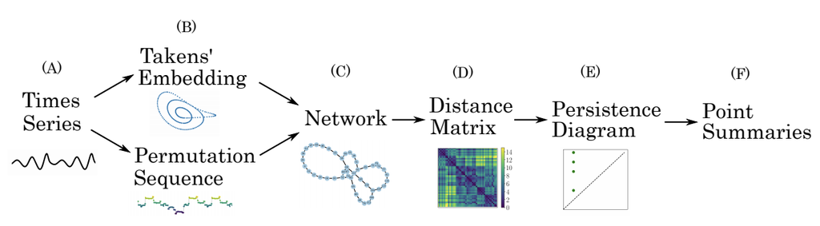

Pipeline

Here is the general pipeline that the [24] follows:

Step 1: Acquire some time series data.

Step 2: Embed a time series using Takens’ embedding or segmenting into a set of permutations.

Step 3: From these two representations, an undirected, unweighted network is formed by either applying a kth nearest neighbors algorithm or by setting each permutation state as a node.

Step 4: The distance matrix is calculated using the shortest path between all nodes.

Step 5: The persistence diagram is generated by applying persistent homology to the distance matrix.

Step 6: One of several point summaries are used to extract information from the persistence diagram.

Here is an example of the pipeline being applied to a periodic Rossler system: [24]

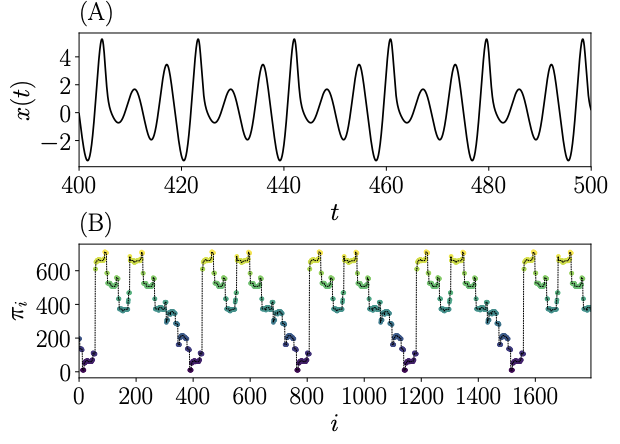

Steps 1 and 2

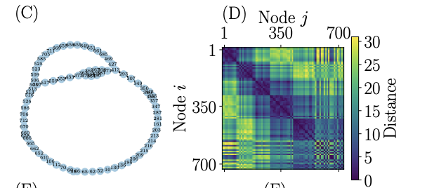

Steps 3 and 4

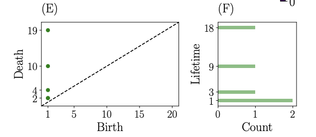

Steps 5 and 6

## Further Research Questions

Some further research questions that have arisen as a result of doing this project are the following:

1. What happens when we create a distance matrix using other metrics, such as the bottleneck distance or the Wasserstein distance?
2. What are some other ways we can create a complex network from time series data?
3. Besides Takens’ theorem and PCA, what are some other embedding techniques we could use on our time series data?
4. How does noise affect the analysis of TDA in the case of studying chaotic systems and strange attractors?
5. How would results change if we tried constructing a network from the recurrence plot?

## Applications of TDA

TDA has several applications in computational biology, physics, medicine, chemistry, neuroscience, and more. For example, TDA can be used to model the brain as a simplicial complex or model the shape of molecules and trees. Moreover, it is still increasing in popularity among applied mathematicians and scientists. The company Ayasdi is also implementing TDA and promoting its use in the machine learning community. It will be difficult for TDA to gain traction among several businesses since the theoretical background and the learning curve for TDA is steep, even for undergraduates in STEM programs. However, I believe that with time, it will become more accessible for more and more data professionals and undergraduates across the world.

## Conclusion and Future Directions

My project focused on the introductory theory in Steps 2, 4, and 5. We briefly mentioned networks since they do have a role in Step 3. The distance matrix we constructed was the recurrence plot. A future project could explore Steps 3 and 6. This pipeline does not need to be restricted to synthetic data like known chaotic dynamical systems. It could also be applied to HRV data time series, for example.

One direction that this project did not take is that we did not discuss the analysis of the output of the TDA in great detail. We merely discussed persistence landscapes and some aspects of hypothesis testing. The goal of this project was to connect the theory of dynamical systems to applied algebraic topology with nonlinear time series. Furthermore, we attempted this at the level of an undergraduate student. Therefore, a deep theoretical examination of TDA and an exploration of the underlying theory of algebraic topology may be useful in future projects. Moreover, confidence intervals, dendrograms, clustering, and random forests could also be used to analyze the output of TDA. In a future project, we may focus on the interpretation of the output of TDA and what it means for a particular data set, such as heart-rate variability. We could also explore other techniques from TDA, such as cubical homology, zig-zag homology, persistent homology on higher dimensional data, and more.

## References:

[1] https://giotto.ai/theory

[2] “Time Series Analysis and Its Applications” - Shumway et al.

[3] “Nonlinear Dynamics and Chaos with Applications in Biology, Chemistry, and Engineering” - Steven Strogatz

[4] “Nonlinear Time Series Analysis with R” - Ray Huffaker et al.

[5] “An Introduction to Chaotic Dynamical Systems” - Robert Devaney

[6] https://en.wikipedia.org/wiki/List_of_fractals_by_Hausdorff_dimension

[7] https://homepage.univie.ac.at/robert.kunst/nonlin.pdf

[8] https://en.wikipedia.org/wiki/Cobweb_plot#cite_note-stoop-1

[9] https://rdrr.io/cran/nonlinearTseries/man/poincareMap.html#heading-7

[10] https://cran.r-project.org/web/packages/tseriesChaos/tseriesChaos.pdf

[11] https://cran.r-project.org/web/packages/nonlinearTseries/vignettes/nonlinearTseries_quickstart.html

[12] https://cran.r-project.org/web/packages/crqa/index.html

[13] https://kateto.net/networks-r-igraph

[14] https://www.youtube.com/watch?v=rlI1KOo1gp4

[15] https://www.youtube.com/watch?v=h0bnG1Wavag

[16] https://arxiv.org/pdf/1506.08903.pdf

[17] https://files.eric.ed.gov/fulltext/EJ1149275.pdf

[18] https://en.wikipedia.org/wiki/Topological_data_analysis

[19] http://www.stat.cmu.edu/topstat/topstat_old/Talks/files/Jisu_150623_TDA_tutorial.pdf

[20] https://cran.r-project.org/web/packages/TDAstats/vignettes/inference.html

[21] https://www.youtube.com/watch?v=q7VVrgykPrw

[22] http://www.jmlr.org/papers/volume16/bubenik15a/bubenik15a.pdf

[23] https://geometrica.saclay.inria.fr/team/Steve.Oudot/courses/TUM/TP/index.html#landscapes

[24] https://arxiv.org/pdf/1904.07403.pdf

[25] https://arxiv.org/pdf/1510.06933.pdf

[26] https://arxiv.org/pdf/1909.10604.pdf

[27] https://www.ams.org/journals/notices/201905/rnoti-p686.pdf